# An Introduction to Statistical Learning (2013)

Solutions to Applied Exercises

by Brian Hassett

# Chapter 7 Moving Beyond Linearity

This notebook is a rough outline of solutions to the applied exercises in Chapter 7 of **An Introduction to Statistical Learning** (James et al. (2013)[^1]).

## Setup

```r
library(ISLR)
library(MASS)
library(tidyverse)
library(patchwork)
library(GGally)
library(splines)
library(gam)
theme_set(theme_bw())

# Given a filename, return the filepath. Default folder is the `data` folder in the current working directory.
get_path <- function(filename) {
  str_c(getwd(), "data", filename, sep = "/")
}

# Colors:
ISLR_blue <- "#176FC0"
ISLR_brown <- "#94340E"
ISLR_lightblue <- "#68A5DB"
ISLR_orange <- "#CC5318"

# Return vector of the names of numeric columns in a data frame:
numeric_cols <- function(df) {
  is_numeric_cols <- map_lgl(df, is.numeric)
  return(names(df)[is_numeric_cols])
}

# predict() function for regsubsets() as given in the book:
predict.regsubsets <- function(object, newdata, id,...) {
  form <- as.formula(object$call[[2]])
  mat <- model.matrix(form, newdata)
  coefi <- coef(object, id=id)
  xvars <- names(coefi)
  mat[, xvars]%*%coefi
}

# Print accuracy, test rate and table of predicted labels and true labels:
test_rates <- function(predicted_label, test_label) {
  print(table(predicted_label, test_label))
  test_accuracy <- mean(predicted_label == test_label)*100
  test_error <- mean(predicted_label != test_label)*100
  print(str_interp("Test accuracy: ${round(test_accuracy, 2)}"))
  print(str_interp("Test error rate: ${round(test_error, 2)}"))
}

# Load my functions:
source("/home/brian/R/dir/Util/bh_functions.R")
```

## Exercise 6

View data:

```r
Wage
```

|  | year | age | maritl | race | education | region | jobclass | health | health_ins | logwage | wage |
| --- | --- | --- | --- | --- | --- | --- | --- | --- | --- | --- | --- |
| 231655 | 2006 | 18 | 1. Never Married | 1. White | 1. < HS Grad | 2. Middle Atlantic | 1. Industrial | 1. <=Good | 2. No | 4.318063 | 75.04315 |
| 86582 | 2004 | 24 | 1. Never Married | 1. White | 4. College Grad | 2. Middle Atlantic | 2. Information | 2. >=Very Good | 2. No | 4.255273 | 70.47602 |
| 161300 | 2003 | 45 | 2. Married | 1. White | 3. Some College | 2. Middle Atlantic | 1. Industrial | 1. <=Good | 1. Yes | 4.875061 | 130.98218 |
| 155159 | 2003 | 43 | 2. Married | 3. Asian | 4. College Grad | 2. Middle Atlantic | 2. Information | 2. >=Very Good | 1. Yes | 5.041393 | 154.68529 |
| 11443 | 2005 | 50 | 4. Divorced | 1. White | 2. HS Grad | 2. Middle Atlantic | 2. Information | 1. <=Good | 1. Yes | 4.318063 | 75.04315 |
| 376662 | 2008 | 54 | 2. Married | 1. White | 4. College Grad | 2. Middle Atlantic | 2. Information | 2. >=Very Good | 1. Yes | 4.845098 | 127.11574 |
| 450601 | 2009 | 44 | 2. Married | 4. Other | 3. Some College | 2. Middle Atlantic | 1. Industrial | 2. >=Very Good | 1. Yes | 5.133021 | 169.52854 |
| 377954 | 2008 | 30 | 1. Never Married | 3. Asian | 3. Some College | 2. Middle Atlantic | 2. Information | 1. <=Good | 1. Yes | 4.716003 | 111.72085 |
| 228963 | 2006 | 41 | 1. Never Married | 2. Black | 3. Some College | 2. Middle Atlantic | 2. Information | 2. >=Very Good | 1. Yes | 4.778151 | 118.88436 |
| 81404 | 2004 | 52 | 2. Married | 1. White | 2. HS Grad | 2. Middle Atlantic | 2. Information | 2. >=Very Good | 1. Yes | 4.857332 | 128.68049 |

[output cut: 990 more lines]

### (a)

Perform polynomial regression to predict `wage` using `age.` Use cross-validation to select the optimal degree $d$ for the polynomial.

```r
### Train/Test
set.seed(1)
n <- nrow(Wage)
d.max <- 5 # max degree of polynomial
train <- sample(n, 4*n/5) # 80%/20% train/test
test <- (-train)

### CV
k = 10
folds <- sample(1:k, nrow(Wage[train, ]), replace=TRUE)
cv.errors <- matrix(NA, k, d.max, dimnames=list(NULL, paste(1:d.max)))
```

### Training

Perform CV on the training data to select the optimum value of $d$ for polynomial regression:

```r
for(j in 1:k) {
  for(i in 1:d.max) {
    fit <- lm(wage ~ poly(age, i), data = Wage[train, ][folds!=j, ])
    pred <- predict(fit, newdata = Wage[train, ][folds==j, ])
    cv.errors[j, i] <- mean((pred - Wage$wage[train][folds==j])^2)
  }
}
mean.cv.errors <- apply(cv.errors, 2, mean)
d.min <- which.min(mean.cv.errors)
sort(mean.cv.errors)
```

```
       4        5        3        2        1
1501.181 1501.978 1503.196 1507.334 1582.349
```

Plot the CV errors for each $d$:

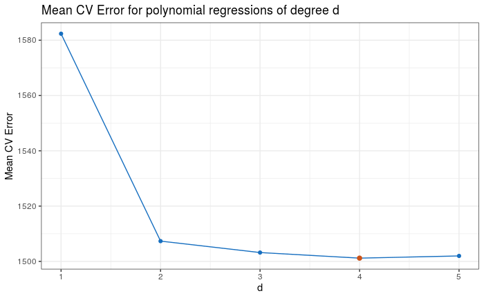

```r
data.frame(d = 1:d.max, error = mean.cv.errors) %>%
  ggplot(aes(d, error)) +
  geom_line(color = ISLR_blue) +
  geom_point(color = ISLR_blue) +
  geom_point(data = data.frame(x = which.min(mean.cv.errors), y = mean.cv.errors[which.min(mean.cv.errors)]),
             aes(x, y), color = ISLR_orange, size = 2) +
  labs(y = "Mean CV Error", title = "Mean CV Error for polynomial regressions of degree d")
```

### Test Error

Fit a model using the optimum $d$, then calculate the error on the test data:

```r
fit <- lm(wage ~ poly(age, d.min), data = Wage[train, ])
pred <- predict(fit, newdata = Wage[test, ])
mse <- mean((pred - Wage$wage[test])^2)
mse
```

```
[1] 1988.348
```

Calculate the R-squared value:

```r
R_sq <- 1 - mse / mean((mean(Wage$wage[test]) - Wage$wage[test])^2)
R_sq
```

```
[1] 0.06636113
```

### Fit final model

Fit a final model on the whole data set and plot the fit:

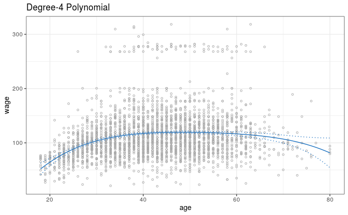

```r
agelims <- range(Wage$age)
age.grid <- seq(agelims[1], agelims[2])
fit <- lm(wage ~ poly(age, d.min), data = Wage)
preds <- predict(fit, newdata = list(age = age.grid), se = TRUE)
#se.bands <- cbind(preds$fit + 2*preds$se.fit, preds$fit - 2*preds$se.fit)

fit_df <- data.frame(
  age = age.grid,
  pred = preds$fit,
  se.upper = preds$fit + 2*preds$se.fit,
  se.lower = preds$fit - 2*preds$se.fit
)
ggplot() +
  geom_point(data = Wage,
             aes(age, wage),
             color = "darkgrey",
             size = 1,
             shape = 21) +
  geom_line(data = fit_df,
            aes(age, pred),
            color = ISLR_blue) +
  geom_line(data = fit_df,
            aes(age, se.upper),
            color = ISLR_blue,
            linetype = "dotted") +
  geom_line(data = fit_df,
            aes(age, se.lower),
            color = ISLR_blue,
            linetype = "dotted") +
  ggtitle(str_interp("Degree-${d.min} Polynomial"))
```

### ANOVA

Perform ANOVA on the full data set:

```r
fit.1 <- lm(wage ~ age, data = Wage)
fit.2 <- lm(wage ~ poly(age, 2), data = Wage)
fit.3 <- lm(wage ~ poly(age, 3), data = Wage)
fit.4 <- lm(wage ~ poly(age, 4), data = Wage)
fit.5 <- lm(wage ~ poly(age, 5), data = Wage)
anova(fit.1, fit.2, fit.3, fit.4, fit.5)
```

```
Analysis of Variance Table

Model 1: wage ~ age
Model 2: wage ~ poly(age, 2)
Model 3: wage ~ poly(age, 3)
Model 4: wage ~ poly(age, 4)
Model 5: wage ~ poly(age, 5)
  Res.Df     RSS Df Sum of Sq        F    Pr(>F)
1   2998 5022216
2   2997 4793430  1    228786 143.5931 < 2.2e-16 ***
3   2996 4777674  1     15756   9.8888  0.001679 **
4   2995 4771604  1      6070   3.8098  0.051046 .
5   2994 4770322  1      1283   0.8050  0.369682
---
Signif. codes:  0 ‘***’ 0.001 ‘**’ 0.01 ‘*’ 0.05 ‘.’ 0.1 ‘ ’ 1
```

The results of ANOVA also suggest that a degree-4 polynomial is the best fit.

Summary of the degree-4 polynomial fit:

```r
summary(fit)
```

```
Call:
lm(formula = wage ~ poly(age, d.min), data = Wage)

Residuals:
    Min      1Q  Median      3Q     Max
-98.707 -24.626  -4.993  15.217 203.693

Coefficients:
                   Estimate Std. Error t value Pr(>|t|)
(Intercept)        111.7036     0.7287 153.283  < 2e-16 ***
poly(age, d.min)1  447.0679    39.9148  11.201  < 2e-16 ***
poly(age, d.min)2 -478.3158    39.9148 -11.983  < 2e-16 ***
poly(age, d.min)3  125.5217    39.9148   3.145  0.00168 **
poly(age, d.min)4  -77.9112    39.9148  -1.952  0.05104 .
---
Signif. codes:  0 ‘***’ 0.001 ‘**’ 0.01 ‘*’ 0.05 ‘.’ 0.1 ‘ ’ 1

Residual standard error: 39.91 on 2995 degrees of freedom
Multiple R-squared:  0.08626,   Adjusted R-squared:  0.08504
F-statistic: 70.69 on 4 and 2995 DF,  p-value: < 2.2e-16
```

### (b)

Fit a step function to predict `wage` using `age`, and perform cross-validation to choose the optimal number of cuts, $c$.

### Training

Perform CV on the training data to select the optimum value of $c$:

```r
set.seed(1)
c.max <- 15 # max number of cuts
age.min = min(Wage$age) - 0.1 # Take away 0.1 for cut()
age.max = max(Wage$age) + 0.1 # Add 0.1 for cut()
k <- 10 # small k is required to avoid error
folds <- sample(1:k, nrow(Wage[train, ]), replace=TRUE)
cv.errors <- matrix(NA, k, c.max, dimnames=list(NULL, paste(1:c.max)))
for(j in 1:k) {
  for(i in 2:c.max) {
    breaks <- seq(age.min, age.max, length.out = i + 1) # see note [1]
    fit <- lm(wage ~ cut(age, breaks), data = Wage[train, ][folds!=j, ])
    pred <- predict(fit, newdata = Wage[train, ][folds==j, ])
    cv.errors[j, i] <- mean((pred - Wage$wage[train][folds==j])^2)
  }
}

# [1] The breaks are calculated explicitly so that the same breaks are used for all folds. If the cut() function is allowed to automatically choose the breaks ( ie `cut(age, i)` ), then errors will arise as different folds will have different breaks.

mean.cv.errors <- apply(cv.errors, 2, mean)
c.min <- which.min(mean.cv.errors)
sort(mean.cv.errors)
```

```
      11        8       12       13       15       10        7       14        9        6        5        4        3        2
1505.999 1508.259 1508.821 1511.219 1512.516 1514.504 1516.421 1517.186 1519.339 1524.481 1535.584 1542.932 1587.657 1637.830
```

Plot the CV errors for each $c$:

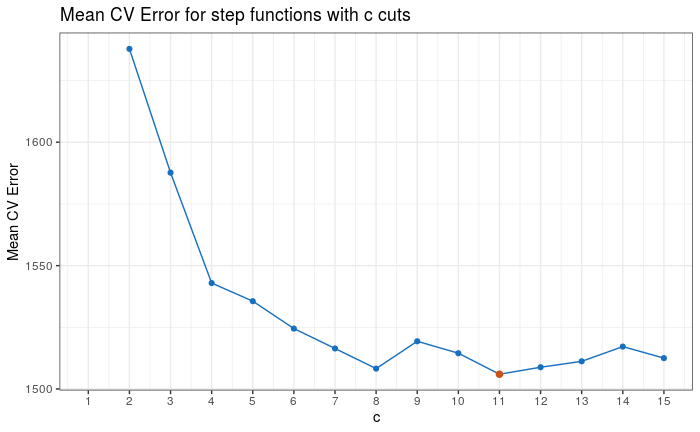

```r
data.frame(c = 1:c.max, error = mean.cv.errors) %>%
  ggplot(aes(c, error)) +
  geom_line(color = ISLR_blue) +
  geom_point(color = ISLR_blue) +
  geom_point(data = data.frame(x = which.min(mean.cv.errors), y = mean.cv.errors[which.min(mean.cv.errors)]),
             aes(x, y), color = ISLR_orange, size = 2) +
  scale_x_continuous(breaks = 1:c.max) +
  labs(y = "Mean CV Error", title = "Mean CV Error for step functions with c cuts")
```

Cross validation on the training set has chosen 11 cuts as optimal.

### Test Error

Fit a model using the optimum $c$, then calculate the error on the test data:

```r
breaks <- seq(age.min, age.max, length.out = c.min + 1)
fit <- lm(wage ~ cut(age, breaks), data = Wage[train, ])
pred <- predict(fit, newdata = Wage[test, ])
mse <- mean((pred - Wage$wage[test])^2)
mse
```

```
[1] 1996.328
```

Calculate the R-squared value:

```r
R_sq <- 1 - mse / mean((mean(Wage$wage[test]) - Wage$wage[test])^2)
R_sq
```

```
[1] 0.06261399
```

### Fit final model

Fit a final model on the whole data set and plot the fit:

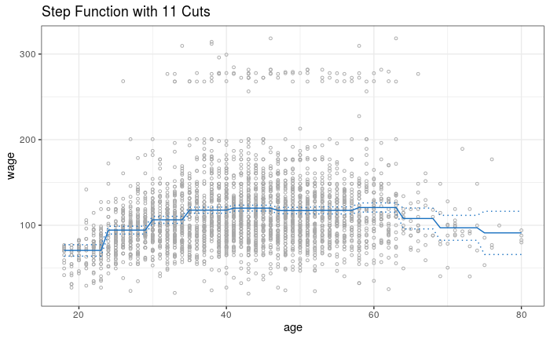

```r
agelims <- range(Wage$age)
age.grid <- seq(agelims[1], agelims[2])
fit <- lm(wage ~ cut(age, c.min), data = Wage)
preds <- predict(fit, newdata = list(age = age.grid), se = TRUE)

fit_df <- data.frame(
  age = age.grid,
  pred = preds$fit,
  se.upper = preds$fit + 2*preds$se.fit,
  se.lower = preds$fit - 2*preds$se.fit
)
ggplot() +
  geom_point(data = Wage,
             aes(age, wage),
             color = "darkgrey",
             size = 1,
             shape = 21) +
  geom_line(data = fit_df,
            aes(age, pred),
            color = ISLR_blue) +
  geom_line(data = fit_df,
            aes(age, se.upper),
            color = ISLR_blue,
            linetype = "dotted") +
  geom_line(data = fit_df,
            aes(age, se.lower),
            color = ISLR_blue,
            linetype = "dotted") +
  ggtitle(str_interp("Step Function with ${c.min} Cuts"))
```

## Exercise 7

View summary of data:

```r
summary(Wage)
```

```
      year           age                     maritl           race                   education                     region
 Min.   :2003   Min.   :18.00   1. Never Married: 648   1. White:2480   1. < HS Grad      :268   2. Middle Atlantic   :3000
 1st Qu.:2004   1st Qu.:33.75   2. Married      :2074   2. Black: 293   2. HS Grad        :971   1. New England       :   0
 Median :2006   Median :42.00   3. Widowed      :  19   3. Asian: 190   3. Some College   :650   3. East North Central:   0
 Mean   :2006   Mean   :42.41   4. Divorced     : 204   4. Other:  37   4. College Grad   :685   4. West North Central:   0
 3rd Qu.:2008   3rd Qu.:51.00   5. Separated    :  55                   5. Advanced Degree:426   5. South Atlantic    :   0
 Max.   :2009   Max.   :80.00                                                                    6. East South Central:   0
                                                                                                 (Other)              :   0
           jobclass               health      health_ins      logwage           wage
 1. Industrial :1544   1. <=Good     : 858   1. Yes:2083   Min.   :3.000   Min.   : 20.09
 2. Information:1456   2. >=Very Good:2142   2. No : 917   1st Qu.:4.447   1st Qu.: 85.38
                                                           Median :4.653   Median :104.92
                                                           Mean   :4.654   Mean   :111.70
                                                           3rd Qu.:4.857   3rd Qu.:128.68
                                                           Max.   :5.763   Max.   :318.34
```

### Variable Selection:

Variable selection and regression (see separate notebook caller `chap7_q7_regression.Rmd`) chose a lasso regression as the best fit. Fit a polynomial regression model using polynomial transformations of `year` and `age`, combined with the `maritl` and `race` variables which were included in the lasso model:

```r
### Data:
data <- Wage # `data` is the full data set
y.index = 11 # column index of response variable

X <- data[ , -c(y.index, 6)]
y <- data[, y.index]
n = nrow(X)
p = ncol(X)
var.names <- names(X)
df <- data.frame(X, y) # data.frame for use in modeling

### Train/Test
set.seed(1)
n <- nrow(Wage)
d.max <- 5 # max degree of polynomial
train <- sample(n, 4*n/5) # 80%/20% train/test
test <- (-train)

### CV
k = 10 # no. of folds
d.max <- 5
folds <- sample(1:k, nrow(Wage[train, ]), replace=TRUE)
cv.errors <- array(NA, c(k, d.max, d.max), dimnames=list(NULL, paste("d_1:", 1:d.max), paste("d_2:", 1:d.max)))
```

#### Training

Perform cross validation on the training data to select the optimum value of $d$ for polynomial regression:

```r
for(j in 1:k) {
  for(d_1 in 1:d.max) { # d_1 : year
    for(d_2 in 1:d.max) { # d_2 : age
      fit <- lm(wage ~ poly(year, d_1) + poly(age, d_2) + maritl + race, data = Wage[train, ][folds!=j, ])
      pred <- predict(fit, newdata = Wage[train, ][folds==j, ])
      cv.errors[j, d_1, d_2] <- mean((pred - Wage$wage[train][folds==j])^2)
    }
  }
}
mean.cv.errors <- apply(cv.errors, c(2, 3), mean)
d.min <- arrayInd(which.min(mean.cv.errors), dim(mean.cv.errors))
d.min # the first number is the polynomial degree for year, the second is age
```

```
     [,1] [,2]
[1,]    3    4
```

#### Test Error

Fit a model on all of the training data using the optimum values for $d$, then calculate the error on the test data:

```r
fit <- lm(wage ~ poly(year, d.min[1]) + poly(age, d.min[2]) + maritl + race, data = Wage[train, ])
pred <- predict(fit, newdata = Wage[test, ])
mse <- mean((pred - Wage$wage[test])^2) # MSE
mse
```

```
[1] 1920.766
```

Calculate the R-squared value:

```r
R_sq <- 1 - mse / mean((mean(Wage$wage[test]) - Wage$wage[test])^2)
R_sq
```

```
[1] 0.09809457
```

### Alternative Model:

To aid in deciding what variables to include in our model, plot the categorical variables against `wage`:

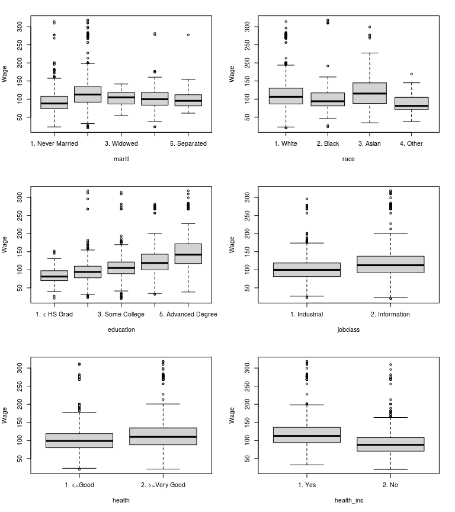

```r
par(mfrow = c(3, 2))
for(i in c(3, 4, 5, 7, 8, 9)) {
  plot(Wage[, i], Wage$wage, ylab = "Wage", xlab = names(Wage[i]))
}
```

Perform Kruskal-Wallis tests for each variable against `wage` to test for differences among the groups:

```r
kw_test <- map(Wage[c(3, 4, 5, 7, 8, 9)], ~kruskal.test(Wage$wage ~ .x))
kw_test
```

```
$maritl

    Kruskal-Wallis rank sum test

data:  Wage$wage by .x
Kruskal-Wallis chi-squared = 292.25, df = 4, p-value < 2.2e-16


$race

    Kruskal-Wallis rank sum test

data:  Wage$wage by .x
Kruskal-Wallis chi-squared = 49.287, df = 3, p-value = 1.133e-10


$education

    Kruskal-Wallis rank sum test

data:  Wage$wage by .x
Kruskal-Wallis chi-squared = 767.05, df = 4, p-value < 2.2e-16


$jobclass

    Kruskal-Wallis rank sum test

data:  Wage$wage by .x
Kruskal-Wallis chi-squared = 130.36, df = 1, p-value < 2.2e-16


$health

    Kruskal-Wallis rank sum test

data:  Wage$wage by .x
Kruskal-Wallis chi-squared = 75.027, df = 1, p-value < 2.2e-16


$health_ins

    Kruskal-Wallis rank sum test

data:  Wage$wage by .x
Kruskal-Wallis chi-squared = 417.78, df = 1, p-value < 2.2e-16
```

Inspect the p-values:

```r
map_dbl(kw_test, ~.x$p.value)
```

```
       maritl          race     education      jobclass        health    health_ins
 5.078140e-62  1.133491e-10 1.053302e-164  3.412809e-30  4.642106e-18  7.413034e-93
```

All 6 factor variables appear to show significant differences among the groups. Create a model with polynomial transformations of `year` and `age` using the values for $d$ found by cross validation. Then add all factor variables to the model and calculate the test error:

```r
fit <- lm(wage ~ poly(year, d.min[1]) + poly(age, d.min[2]) + maritl + race + education + jobclass + health + health_ins, data = Wage[train, ])
pred <- predict(fit, newdata = Wage[test, ])
mse <- mean((pred - Wage$wage[test])^2) # MSE
mse
```

```
[1] 1428.355
```

Calculate the R-squared value:

```r
R_sq <- 1 - mse / mean((mean(Wage$wage[test]) - Wage$wage[test])^2)
R_sq
```

```
[1] 0.3293089
```

The test error and the R-squared value are now much better, and are comparable with that of the lasso regression.

## Exercise 8

View data:

```r
Auto
```

|  | mpg | cylinders | displacement | horsepower | weight | acceleration | year | origin | name |
| --- | --- | --- | --- | --- | --- | --- | --- | --- | --- |
| 1 | 18.0 | 8 | 307.0 | 130 | 3504 | 12.0 | 70 | 1 | chevrolet chevelle malibu |
| 2 | 15.0 | 8 | 350.0 | 165 | 3693 | 11.5 | 70 | 1 | buick skylark 320 |
| 3 | 18.0 | 8 | 318.0 | 150 | 3436 | 11.0 | 70 | 1 | plymouth satellite |
| 4 | 16.0 | 8 | 304.0 | 150 | 3433 | 12.0 | 70 | 1 | amc rebel sst |
| 5 | 17.0 | 8 | 302.0 | 140 | 3449 | 10.5 | 70 | 1 | ford torino |
| 6 | 15.0 | 8 | 429.0 | 198 | 4341 | 10.0 | 70 | 1 | ford galaxie 500 |
| 7 | 14.0 | 8 | 454.0 | 220 | 4354 | 9.0 | 70 | 1 | chevrolet impala |
| 8 | 14.0 | 8 | 440.0 | 215 | 4312 | 8.5 | 70 | 1 | plymouth fury iii |
| 9 | 14.0 | 8 | 455.0 | 225 | 4425 | 10.0 | 70 | 1 | pontiac catalina |
| 10 | 15.0 | 8 | 390.0 | 190 | 3850 | 8.5 | 70 | 1 | amc ambassador dpl |

[output cut: 382 more lines]

Generate a `pairs()` plot from the numeric variables:

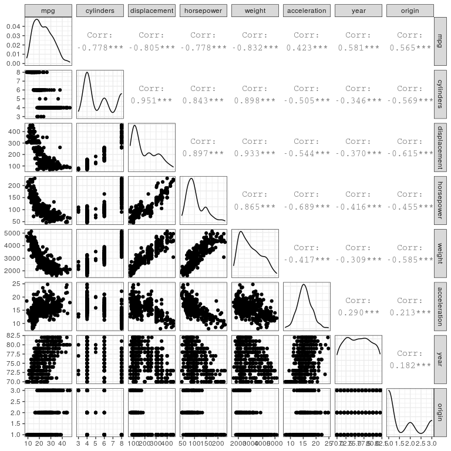

```r
facs <- c(2, 8) # factor variables
nums <- c(1, 3, 4, 5, 6, 7) # numeric variables
ggpairs(Auto[ , -9], progress = FALSE) # exclude the name column
```

From the `pairs()` plot it is apparent that there is a non-linear relationship between `mpg` and `displacement`, `horsepower`, `weight`, and possibly `acceleration`.

Plot the categorical variables against `mpg`:

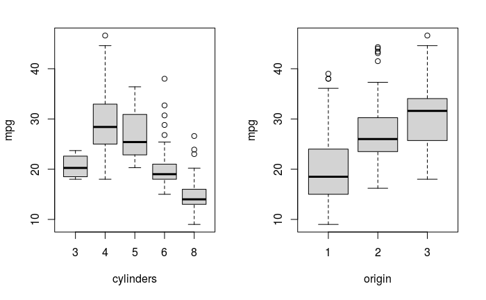

```r
par(mfrow = c(1, 2))
for(i in facs) {
  plot(as.factor(Auto[, i]), Auto$mpg, ylab = "mpg", xlab = names(Auto[i]))
}
```

There seems to be an obvious difference among the groups; perform Kruskal-Wallis tests for each variable against `mpg` to confirm:

```r
kw_test <- map(Auto[ , facs], function(x) kruskal.test(Auto$mpg ~ x))
kw_test
```

```
$cylinders

    Kruskal-Wallis rank sum test

data:  Auto$mpg by x
Kruskal-Wallis chi-squared = 280.41, df = 4, p-value < 2.2e-16


$origin

    Kruskal-Wallis rank sum test

data:  Auto$mpg by x
Kruskal-Wallis chi-squared = 132.09, df = 2, p-value < 2.2e-16
```

Inspect the p-values:

```r
map_dbl(kw_test, function(x) x$p.value)
```

```
   cylinders       origin
1.821899e-59 2.078165e-29
```

The p-values indicate significant differences among the groups, so we will include these in the model.

Prepare the data:

```r
data <- Auto # `data` is the full data set

print_names <- function(data) {
  map2_chr(1:ncol(data), names(data), function(i, n) str_c(i, ": ", n))
}
print_names(data)
```

```
[1] "1: mpg"          "2: cylinders"    "3: displacement" "4: horsepower"   "5: weight"       "6: acceleration" "7: year"
[8] "8: origin"       "9: name"
```

```r
y.index = 1 # column index of response variable

X <- data[ , -c(y.index, 9)]
y <- data[, y.index]
n = nrow(X)
p = ncol(X)
var.names <- names(X)
df <- data.frame(X, y) # data.frame for use in modeling

### Train/Test
train <- sample(n, 4*n/5) # 80%/20% train/test
test <- (-train)
MSE = c() # test errors

### CV
k = 10
d.max <- 5
folds <- sample(1:k, nrow(X[train, ]), replace=TRUE)
cv.errors <- array(NA, c(k, d.max, d.max, d.max), dimnames=list(NULL, paste("d_1:", 1:d.max), paste("d_2:", 1:d.max), paste("d_3:", 1:d.max)))
```

Use cross validation to generate a polynomial regression model (keep `acceleration` as a linear variable for now):

```r
for(j in 1:k) {
  for(d_1 in 1:d.max) { # d_1 : displacement
    for(d_2 in 1:d.max) { # d_2 : horsepower
      for(d_3 in 1:d.max) { # d_3 : weight
        fit <- lm(mpg ~
                    poly(displacement, d_1) +
                    poly(horsepower, d_2) +
                    poly(weight, d_3) +
                    acceleration + year + cylinders + origin,
                  data = Auto[train, ][folds !=j, ]
        )
        pred <- predict(fit, newdata = Auto[train, ][folds==j, ])
        cv.errors[j, d_1, d_2, d_3] <- mean((pred - Auto$mpg[train][folds==j])^2)
      }
    }
  }
}
```

Find the optimum values of $d$:

```r
mean.cv.errors <- apply(cv.errors, c(2, 3, 4), mean)
d.min <- arrayInd(which.min(mean.cv.errors), dim(mean.cv.errors))
d.min # displacement, horsepower, weight
```

```
     [,1] [,2] [,3]
[1,]    2    3    1
```

### Test Error

Fit a model on all of the training data using the optimum values for $d$, then calculate the error on the test data:

```r
fit <- lm(mpg ~
            poly(displacement, d.min[1]) +
            poly(horsepower, d.min[2]) +
            poly(weight, d.min[3]) +
            acceleration + year + cylinders + origin,
          data = Auto[train, ]
)
pred <- predict(fit, newdata = Auto[test, ])
mse <- mean((pred - Auto$mpg[test])^2) # MSE
mse
```

```
[1] 10.49344
```

Calculate the R-squared value:

```r
R_sq <- 1 - mse / mean((mean(Auto$mpg[test]) - Auto$mpg[test])^2)
R_sq
```

```
[1] 0.8448975
```

This model outperforms all of the regression models made using variable selection methods in `chap7_q8_regression.Rmd` (this is a separate notebook where I performed the other regression method discussed in the book to see how they compare):

```r
structure(c(11.9316552792546, 12.3233068395963, 13.2114834420672,
13.3603145148612, 15.4494644538557), .Names = c("reg.best.MSE", "lasso.MSE",
"pls.MSE", "ridge.MSE", "pcr.MSE"))
```

```
reg.best.MSE    lasso.MSE      pls.MSE    ridge.MSE      pcr.MSE
    11.93166     12.32331     13.21148     13.36031     15.44946
```

```r
structure(c(0.81812145255292, 0.81215136581867, 0.79861256784361,
0.796343881839762, 0.764498211862678), .Names = c("reg.best.R2",
"lasso.R2", "pls.R2", "ridge.R2", "pcr.R2"))
```

```
reg.best.R2    lasso.R2      pls.R2    ridge.R2      pcr.R2
  0.8181215   0.8121514   0.7986126   0.7963439   0.7644982
```

## Exercise 9

View data:

```r
Boston
```

|  | crim | zn | indus | chas | nox | rm | age | dis | rad | tax | ptratio | black | lstat | medv |
| --- | --- | --- | --- | --- | --- | --- | --- | --- | --- | --- | --- | --- | --- | --- |
| 1 | 0.00632 | 18.0 | 2.31 | 0 | 0.5380 | 6.575 | 65.2 | 4.0900 | 1 | 296 | 15.3 | 396.90 | 4.98 | 24.0 |
| 2 | 0.02731 | 0.0 | 7.07 | 0 | 0.4690 | 6.421 | 78.9 | 4.9671 | 2 | 242 | 17.8 | 396.90 | 9.14 | 21.6 |
| 3 | 0.02729 | 0.0 | 7.07 | 0 | 0.4690 | 7.185 | 61.1 | 4.9671 | 2 | 242 | 17.8 | 392.83 | 4.03 | 34.7 |
| 4 | 0.03237 | 0.0 | 2.18 | 0 | 0.4580 | 6.998 | 45.8 | 6.0622 | 3 | 222 | 18.7 | 394.63 | 2.94 | 33.4 |
| 5 | 0.06905 | 0.0 | 2.18 | 0 | 0.4580 | 7.147 | 54.2 | 6.0622 | 3 | 222 | 18.7 | 396.90 | 5.33 | 36.2 |
| 6 | 0.02985 | 0.0 | 2.18 | 0 | 0.4580 | 6.430 | 58.7 | 6.0622 | 3 | 222 | 18.7 | 394.12 | 5.21 | 28.7 |
| 7 | 0.08829 | 12.5 | 7.87 | 0 | 0.5240 | 6.012 | 66.6 | 5.5605 | 5 | 311 | 15.2 | 395.60 | 12.43 | 22.9 |
| 8 | 0.14455 | 12.5 | 7.87 | 0 | 0.5240 | 6.172 | 96.1 | 5.9505 | 5 | 311 | 15.2 | 396.90 | 19.15 | 27.1 |
| 9 | 0.21124 | 12.5 | 7.87 | 0 | 0.5240 | 5.631 | 100.0 | 6.0821 | 5 | 311 | 15.2 | 386.63 | 29.93 | 16.5 |
| 10 | 0.17004 | 12.5 | 7.87 | 0 | 0.5240 | 6.004 | 85.9 | 6.5921 | 5 | 311 | 15.2 | 386.71 | 17.10 | 18.9 |

[output cut: 496 more lines]

```r
summary(Boston[, c(5, 8)])
```

```
      nox              dis
 Min.   :0.3850   Min.   : 1.130
 1st Qu.:0.4490   1st Qu.: 2.100
 Median :0.5380   Median : 3.207
 Mean   :0.5547   Mean   : 3.795
 3rd Qu.:0.6240   3rd Qu.: 5.188
 Max.   :0.8710   Max.   :12.127
```

Plot `nox` against `dis`:

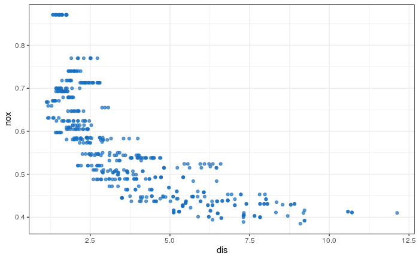

```r
ggplot(Boston) +
  geom_point(aes(dis, nox), color = ISLR_blue, alpha = 0.7)
```

### (a)

Fit a cubic polynomial regression to predict `nox` using `dis`:

```r
dis <- Boston$dis
nox <- Boston$nox
fit <- lm(nox ~ poly(dis, 3), data = Boston)
summary(fit)
```

```
Call:
lm(formula = nox ~ poly(dis, 3), data = Boston)

Residuals:
      Min        1Q    Median        3Q       Max
-0.121130 -0.040619 -0.009738  0.023385  0.194904

Coefficients:
               Estimate Std. Error t value Pr(>|t|)
(Intercept)    0.554695   0.002759 201.021  < 2e-16 ***
poly(dis, 3)1 -2.003096   0.062071 -32.271  < 2e-16 ***
poly(dis, 3)2  0.856330   0.062071  13.796  < 2e-16 ***
poly(dis, 3)3 -0.318049   0.062071  -5.124 4.27e-07 ***
---
Signif. codes:  0 ‘***’ 0.001 ‘**’ 0.01 ‘*’ 0.05 ‘.’ 0.1 ‘ ’ 1

Residual standard error: 0.06207 on 502 degrees of freedom
Multiple R-squared:  0.7148,    Adjusted R-squared:  0.7131
F-statistic: 419.3 on 3 and 502 DF,  p-value: < 2.2e-16
```

Plot the results of the cubic fit:

```r
dis.lims <- range(dis)
dis.grid <- seq(dis.lims[1], dis.lims[2], length = 100)
preds <- predict(fit, newdata = list(dis = dis.grid), se = TRUE)
se.bands <- cbind(preds$fit + 2*preds$se.fit, preds$fit - 2*preds$se.fit)
plot(dis, nox, xlim = dis.lims, cex = 0.5, col = "darkgrey")
title("Cubic Polynomial Regression")
```

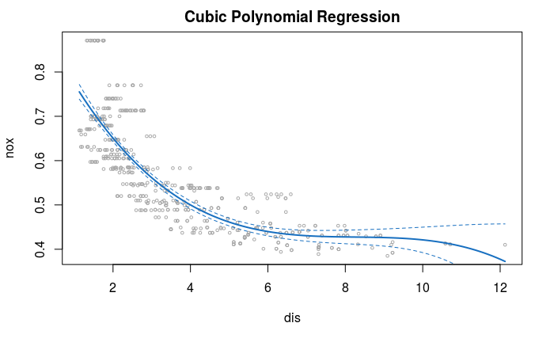

```r
lines(dis.grid, preds$fit, lwd = 2, col = ISLR_blue)
matlines(dis.grid, se.bands, lwd = 1, col = ISLR_blue, lty = 2)
```

### (b)

Fit polynomials of degree 1 to 10:

```r
D <- 1:10 # degrees of polynomial to be considered
fits <- map(D, function(d) fit <- lm(nox ~ poly(dis, d), data = Boston))
fits.summary <- lapply(fits, summary) # purrr::map returning an error here for some reason
fits.rss <- map_dbl(fits.summary, 6) # RSS (sigma) is the 6th element of each summary
preds <- map(fits, function(fit) predict(fit, newdata = list(dis = dis.grid), se = TRUE))
se.bands <- map(preds, function(p) cbind(p$fit + 2*p$se.fit, p$fit - 2*p$se.fit))
rss <- map_dbl(fits, function(fit) with(summary(fit), df[2] * sigma^2))
```

Plot the results:

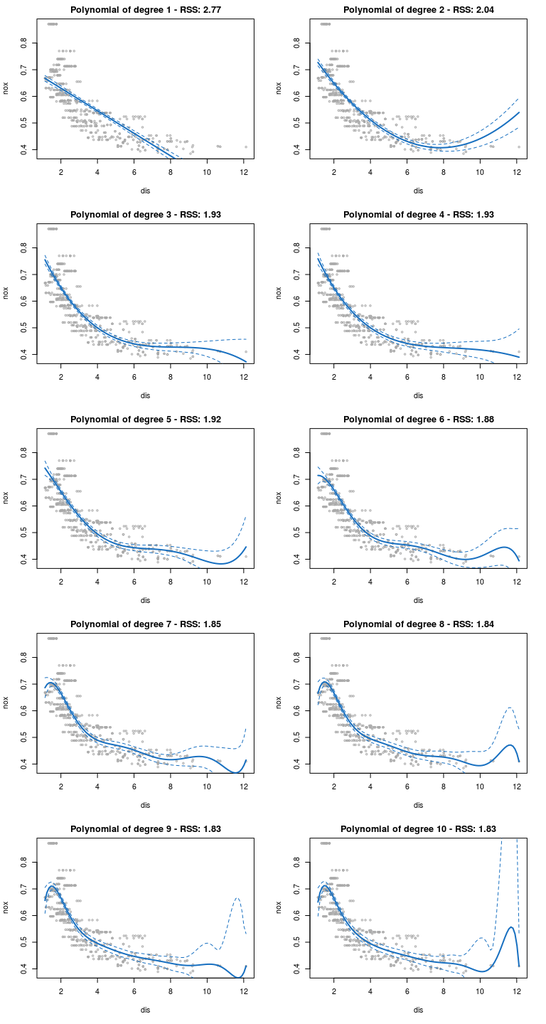

```r
par(mfrow = c(5, 2))
for(i in D) {
  plot(dis, nox, xlim = dis.lims, cex = 0.5, col = "darkgrey")
  title(str_c("Polynomial of degree ", i, " - RSS: ", round(rss[i], 2)))
  lines(dis.grid, preds[[i]]$fit, lwd = 2, col = ISLR_blue)
  matlines(dis.grid, se.bands[[i]], lwd = 1, col = ISLR_blue, lty = 2)
}
```

Plot the RSS values:

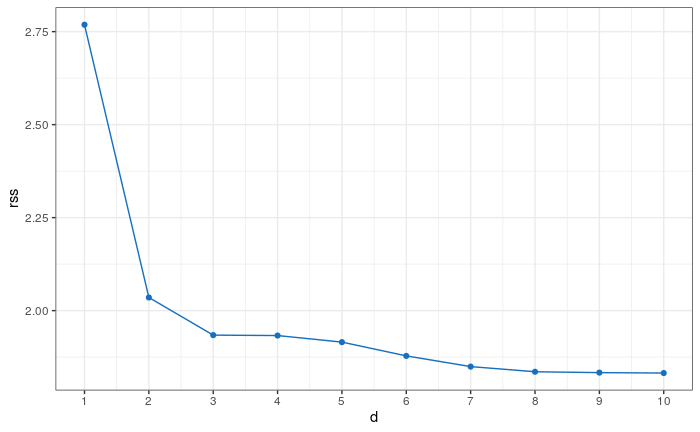

```r
data.frame(d = D, rss) %>%
  ggplot(aes(d, rss)) +
  geom_line(color = ISLR_blue) +
  geom_point(color = ISLR_blue) +
  scale_x_continuous(breaks = D)
```

As expected, the RSS decreases as flexibility increases.

### (c)

Prepare splits and folds for cross-validation:

```r
set.seed(1)
data <- Boston # `data` is the full data set

print_names <- function(data) {
  map2_chr(1:ncol(data), names(data), function(i, n) str_c(i, ": ", n))
}
print_names(data)
```

```
 [1] "1: crim"     "2: zn"       "3: indus"    "4: chas"     "5: nox"      "6: rm"       "7: age"      "8: dis"
 [9] "9: rad"      "10: tax"     "11: ptratio" "12: black"   "13: lstat"   "14: medv"
```

```r
y.index = 5 # column index of response variable

X <- data[ , 8]
y <- data[, y.index]
n = length(X)
p = ncol(X)
var.names <- names(X)
df <- data.frame(X, y) # data.frame for use in modeling

### CV
k = 10
d.max <- 10 # max degree of polynomial
folds <- sample(1:k, length(X), replace=TRUE)
cv.errors <- array(NA, c(k, d.max), dimnames=list(NULL, paste("d_1:", 1:d.max)))
```

Perform CV on **whole data set**:

```r
for(j in 1:k) {
  for(i in 1:d.max) {
    fit <- lm(y ~ poly(X, i), data = df[folds!=j, ])
    pred <- predict(fit, newdata = df[folds==j, ])
    cv.errors[j, d_1] <- mean((pred - y[folds==j])^2)
  }
}
```

CV errors:

```r
mean.cv.errors <- apply(cv.errors, 2, mean)
d.min <- which.min(mean.cv.errors)
d.min
```

```
d_1: 5
     5
```

### (d)

Plot `nox` against `dis`:

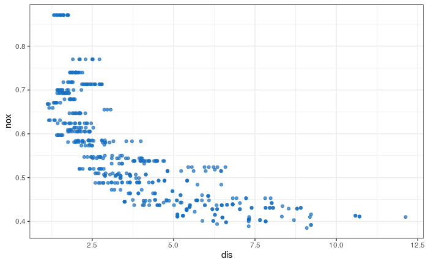

```r
ggplot(Boston) +
  geom_point(aes(dis, nox), color = ISLR_blue, alpha = 0.7)
```

Generate a regression spline using 4 degrees of freedom and plot the resulting fit:

```r
df <- 4
fit <- lm(nox ~ bs(dis, df), data = Boston)
knots <- attr(bs(dis, df), "knots")
preds <- predict(fit, newdata = list(dis = dis.grid), se = TRUE)
se.bands <- cbind(preds$fit + 2*preds$se.fit, preds$fit - 2*preds$se.fit)

plot(dis, nox, xlim = dis.lims, cex = 0.5, col = "darkgrey")
title(str_c("Regression Spline, df = ", df))
```

```r
lines(dis.grid, preds$fit, lwd = 2, col = ISLR_blue)
matlines(dis.grid, se.bands, lwd = 1, col = ISLR_blue, lty = 2)
```

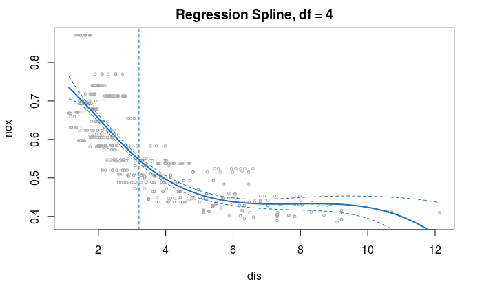

```r
abline(v = knots, lwd = 1, col = ISLR_blue, lty = 2)
```

The knots are chosen automatically by the `bs()` function and are displayed on the plot using vertical lines. For 4 degrees of freedom one knot was chosen which divides the data in two:

```r
knots
```

```
    50%
3.20745
```

### (e)

Generate regression splines using varying degrees of freedom and plot the resulting fits:

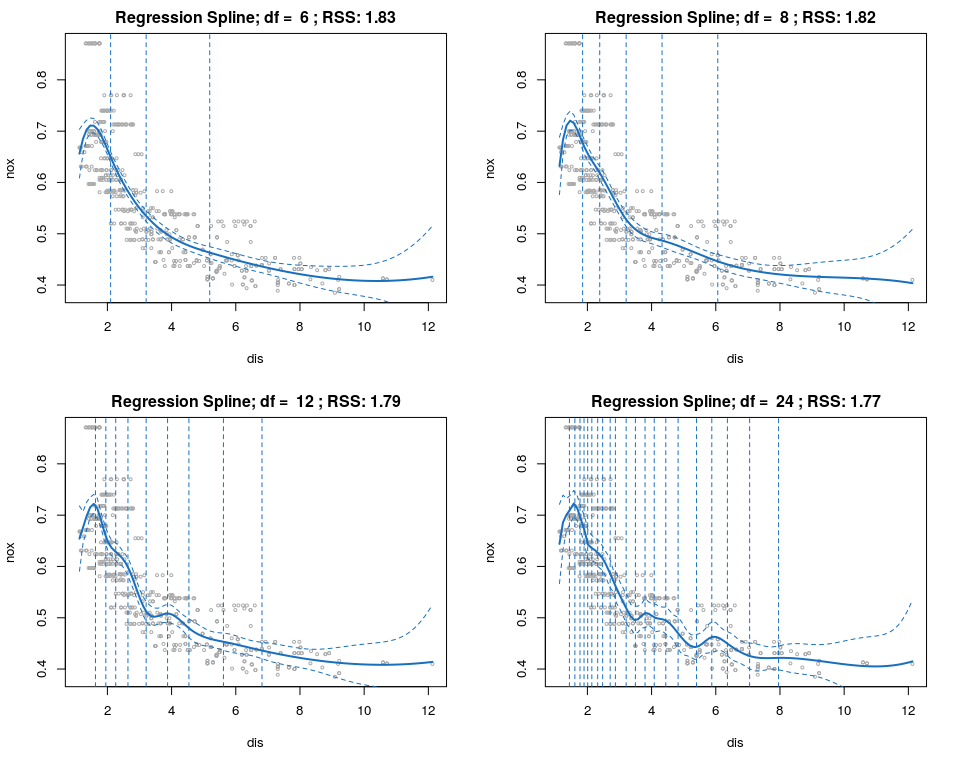

```r
dfs <- c(6, 8, 12, 24) # wide range of degrees of freedom chosen
fits <- map(dfs, function(df) lm(nox ~ bs(dis, df), data = Boston))
knots <- map(dfs, function(df) attr(bs(dis, df), "knots"))
preds <- map(fits, function(fit) predict(fit, newdata = list(dis = dis.grid), se = TRUE))
se.bands <- map(preds, function(p) cbind(p$fit + 2*p$se.fit, p$fit - 2*p$se.fit))
rss <- map_dbl(fits, function(fit) with(summary(fit), df[2] * sigma^2))

# Plot the results:
par(mfrow = c(2, 2))
for(i in 1:length(dfs)) {
  plot(dis, nox, xlim = dis.lims, cex = 0.5, col = "darkgrey")
  title(str_c("Regression Spline; df =  ", dfs[i], " ; RSS: ", round(rss[i], 2)))
  lines(dis.grid, preds[[i]]$fit, lwd = 2, col = ISLR_blue)
  matlines(dis.grid, se.bands[[i]], lwd = 1, col = ISLR_blue, lty = 2)
  abline(v = knots[[i]], lwd = 1, col = ISLR_blue, lty = 2)
}
```

### (f)

Perform cross-validation on the whole data set to select the best degrees of freedom for a regression spline:

```r
set.seed(1)
data <- Boston # `data` is the full data set

print_names <- function(data) {
  map2_chr(1:ncol(data), names(data), function(i, n) str_c(i, ": ", n))
}
print_names(data)
```

```
 [1] "1: crim"     "2: zn"       "3: indus"    "4: chas"     "5: nox"      "6: rm"       "7: age"      "8: dis"
 [9] "9: rad"      "10: tax"     "11: ptratio" "12: black"   "13: lstat"   "14: medv"
```

```r
y.index = 5 # column index of response variable

X <- data[ , 8]
y <- data[, y.index]
n = length(X)
p = ncol(X)
var.names <- names(X)
df <- data.frame(X, y) # data.frame for use in modeling

### CV
k = 10
df.max <- 24 # max degrees of freedom to consider
folds <- sample(1:k, length(X), replace=TRUE)
cv.errors <- array(NA, c(k, df.max), dimnames=list(NULL, paste("df:", 1:df.max)))
rss <- vector("double", length(df.max))
```

Perform CV on whole data set:

```r
for(j in 1:k) {
  for(i in 4:df.max) {
    fit <- lm(y ~ bs(X, df = i), data = df[folds!=j, ])
    pred <- predict(fit, newdata = df[folds==j, ])
    cv.errors[j, i] <- mean((pred - y[folds==j])^2)
    rss[i] <- with(summary(fit), df[2] * sigma^2)
  }
}
```

CV errors:

```r
mean.cv.errors <- apply(cv.errors, 2, mean)
df.min <- which.min(mean.cv.errors)
df.min
```

```
df: 5
    5
```

After cross validation a regression spline with 5 degrees of freedom has the lowest error.

Plot the CV error for each model:

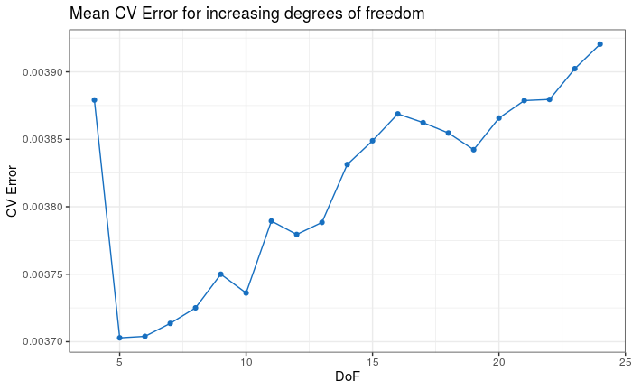

```r
data.frame(dof = 4:df.max, error = mean.cv.errors[4:df.max]) %>%
  ggplot(aes(dof, error)) +
  geom_line(color = ISLR_blue) +
  geom_point(color = ISLR_blue) +
  labs(x = "DoF", y = "CV Error", title = "Mean CV Error for increasing degrees of freedom")
```

The CV error drops sharply from 4 degrees of freedom to 5, and then generally increases as flexibility increases.

Plot the RSS for each model:

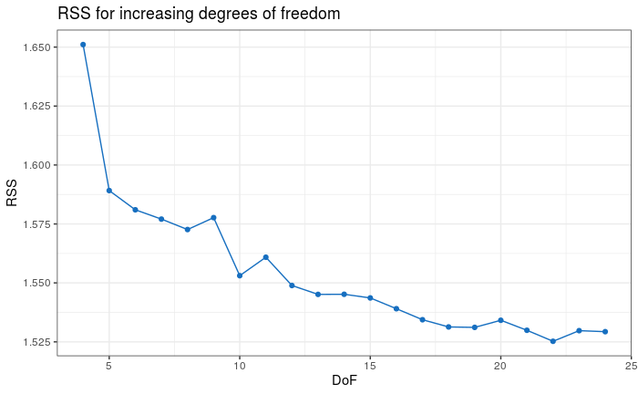

```r
data.frame(dof = 4:df.max, rss = rss[4:df.max]) %>%
  ggplot(aes(dof, rss)) +
  geom_line(color = ISLR_blue) +
  geom_point(color = ISLR_blue) +
  labs(x = "DoF", y = "RSS", title = "RSS for increasing degrees of freedom")
```

As is expected the RSS decreases as the flexibility increases. A model with 5 degrees of freedom seems to have acceptably low RSS compare to the most flexible models. Redo the above plot but start the y-axis at zero to see this:

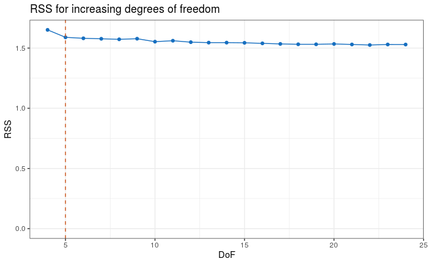

```r
data.frame(dof = 4:df.max, rss = rss[4:df.max]) %>%
  ggplot(aes(dof, rss)) +
  geom_line(color = ISLR_blue) +
  geom_point(color = ISLR_blue) +
  geom_vline(xintercept = df.min, color = ISLR_orange, linetype = "dashed") +
  coord_cartesian(ylim = c(0, NA)) +
  labs(x = "DoF", y = "RSS", title = "RSS for increasing degrees of freedom")
```

## Exercise 10

View data:

```r
College
```

|  | Private | Apps | Accept | Enroll | Top10perc | Top25perc | F.Undergrad | P.Undergrad | Outstate | Room.Board | Books | Personal | PhD | Terminal | S.F.Ratio | perc.alumni | Expend | Grad.Rate |
| --- | --- | --- | --- | --- | --- | --- | --- | --- | --- | --- | --- | --- | --- | --- | --- | --- | --- | --- |
| Abilene Christian University | Yes | 1660 | 1232 | 721 | 23 | 52 | 2885 | 537 | 7440 | 3300 | 450 | 2200 | 70 | 78 | 18.1 | 12 | 7041 | 60 |
| Adelphi University | Yes | 2186 | 1924 | 512 | 16 | 29 | 2683 | 1227 | 12280 | 6450 | 750 | 1500 | 29 | 30 | 12.2 | 16 | 10527 | 56 |
| Adrian College | Yes | 1428 | 1097 | 336 | 22 | 50 | 1036 | 99 | 11250 | 3750 | 400 | 1165 | 53 | 66 | 12.9 | 30 | 8735 | 54 |
| Agnes Scott College | Yes | 417 | 349 | 137 | 60 | 89 | 510 | 63 | 12960 | 5450 | 450 | 875 | 92 | 97 | 7.7 | 37 | 19016 | 59 |
| Alaska Pacific University | Yes | 193 | 146 | 55 | 16 | 44 | 249 | 869 | 7560 | 4120 | 800 | 1500 | 76 | 72 | 11.9 | 2 | 10922 | 15 |
| Albertson College | Yes | 587 | 479 | 158 | 38 | 62 | 678 | 41 | 13500 | 3335 | 500 | 675 | 67 | 73 | 9.4 | 11 | 9727 | 55 |
| Albertus Magnus College | Yes | 353 | 340 | 103 | 17 | 45 | 416 | 230 | 13290 | 5720 | 500 | 1500 | 90 | 93 | 11.5 | 26 | 8861 | 63 |
| Albion College | Yes | 1899 | 1720 | 489 | 37 | 68 | 1594 | 32 | 13868 | 4826 | 450 | 850 | 89 | 100 | 13.7 | 37 | 11487 | 73 |
| Albright College | Yes | 1038 | 839 | 227 | 30 | 63 | 973 | 306 | 15595 | 4400 | 300 | 500 | 79 | 84 | 11.3 | 23 | 11644 | 80 |
| Alderson-Broaddus College | Yes | 582 | 498 | 172 | 21 | 44 | 799 | 78 | 10468 | 3380 | 660 | 1800 | 40 | 41 | 11.5 | 15 | 8991 | 52 |

[output cut: 767 more lines]

### (a)

Split the data into a training set and a test set. Using out-of-state tuition (`Outstate`) as the response and the other variables as the predictors, perform forward stepwise selection on the training set in order to identify a satisfactory model that uses just a subset of the predictors.

```r
### Prelims
library(leaps)
set.seed(1)

### Data
library(ISLR)
attach(College)

data <- College # `data` is the full data set
print_names <- function(data) {
  map2_chr(1:ncol(data), names(data), function(i, n) str_c(i, ": ", n))
}
print_names(data)
```

```
 [1] "1: Private"      "2: Apps"         "3: Accept"       "4: Enroll"       "5: Top10perc"    "6: Top25perc"
 [7] "7: F.Undergrad"  "8: P.Undergrad"  "9: Outstate"     "10: Room.Board"  "11: Books"       "12: Personal"
[13] "13: PhD"         "14: Terminal"    "15: S.F.Ratio"   "16: perc.alumni" "17: Expend"      "18: Grad.Rate"
```

```r
y.index = 9 # column index of response variable

X <- data[ , -c(y.index)]
y <- data[, y.index]
n = nrow(X)
p = ncol(X)
var.names <- names(X)
df <- data.frame(X, y) # data.frame for use in modeling

### Train/Test
train <- sample(n, 4*n/5) # 80%/20% train/test
test <- (-train)
MSE = c() # test errors

# Best Subset
r.max = p # `nvmax` in regsubsets()

### CV
k = 10
folds <- sample(1:k, nrow(X[train, ]), replace=TRUE)
cv.errors <- matrix(NA, k, r.max, dimnames=list(NULL, paste(1:r.max)))
predict.regsubsets <- function(object, newdata, id,...) {
  form <- as.formula(object$call[[2]])
  mat <- model.matrix(form, newdata)
  coefi <- coef(object, id=id)
  xvars <- names(coefi)
  mat[, xvars]%*%coefi
}
```

#### Forward Stepwise Selection

Use forward stepwise selection and cross-validation (on the training set only) to select a model:

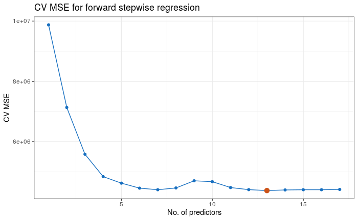

```r
for(j in 1:k) {
  forward.fit <- regsubsets(y ~ ., data=df[train, ][folds!=j, ], nvmax=r.max, method = "forward")
  for(i in 1:r.max) {
    pred <- predict.regsubsets(forward.fit, df[train, ][folds==j, ], id=i)
    cv.errors[j, i] = mean((pred - y[train][folds==j])^2)
  }
}
mean.cv.errors <- apply(cv.errors, 2, mean)
p.min <- which.min(mean.cv.errors)

# Plot errors
data.frame(p = 1:p, error = mean.cv.errors) %>%
  ggplot(aes(p, error)) +
  geom_line(color = ISLR_blue) +
  geom_point(color = ISLR_blue) +
  geom_point(data = data.frame(x = which.min(mean.cv.errors), y = mean.cv.errors[which.min(mean.cv.errors)]),
             aes(x, y), color = ISLR_orange, size = 3) +
  labs(x = "No. of predictors", y = "CV MSE",
       title = "CV MSE for forward stepwise regression")
```

Forward stepwise selection on the training set with cross-validation has chosen the 13-variable model as the model with lowest CV error.

To calculate the test error, we use forward stepwise selection on the training set, then make predictions on the test set using the 13-variable model:

```r
reg.forward <- regsubsets(y ~ ., data=df[train, ], nvmax=r.max, method = "forward")
reg.forward.pred <- predict(reg.forward, df[test, ], id=p.min) #p.min#
reg.forward.test.error <- mean((reg.forward.pred - y[test])^2)
MSE = c(MSE, reg.forward=reg.forward.test.error)
reg.forward.test.error
```

```
[1] 3168461
```

We also calculate the test R Squared:

```r
test.avg <- mean(y[test])
reg.forward.test.r2 <- 1 - reg.forward.test.error / mean((test.avg - y[test])^2)
reg.forward.test.r2
```

```
[1] 0.7741417
```

13 variables is almost all of the variables. When we look at the plot of CV error we see that a model with 6 variables achieves a similar error to 13, but with far fewer variables. A 6-variable model will be easier to work with, so calculate the test error and R-squared value for a forward stepwise selection model with 6 variables.

To calculate the test error for a model with 6 variables, we use forward stepwise selection on the training set, then make predictions on the test set:

```r
p.alt = 6 # Uncomment this to use an alternative no. of variables. Comment lines marked #p.min#. Uncomment lines marked #alt.p#
reg.forward <- regsubsets(y ~ ., data=df[train, ], nvmax=r.max, method = "forward")
reg.forward.pred <- predict(reg.forward, df[test, ], id=p.alt) #p.alt#
reg.forward.test.error <- mean((reg.forward.pred - y[test])^2)
reg.forward.test.error
```

```
[1] 3490466
```

We also calculate the test R Squared:

```r
reg.forward.test.r2 <- 1 - reg.forward.test.error / mean((test.avg - y[test])^2)
reg.forward.test.r2
```

```
[1] 0.7511881
```

The r-squared value for the 6-variable model is comparable with the 13-variable model, but has less than half the predictors.

For the final model, perform forward stepwise seletion on the whole data set and obtain coefficients for the 6-variable model:

```r
reg.forward <- regsubsets(y ~ ., data=df, nvmax=p, method = "forward")
reg.forward.omit <- names(coef(reg.forward, p.alt)[-1]) #p.alt#
round(coef(reg.forward, p.alt), 3) #p.alt#
```

```
(Intercept)  PrivateYes  Room.Board         PhD perc.alumni      Expend   Grad.Rate
  -3553.235    2768.635       0.968      35.528      48.422       0.221      29.712
```

The variables omitted by forward stepwise selection are:

```r
var.names[!var.names %in% names(coef(reg.forward, p.alt)[-1])] #p.alt#
```

```
 [1] "Private"     "Apps"        "Accept"      "Enroll"      "Top10perc"   "Top25perc"   "F.Undergrad" "P.Undergrad"
 [9] "Books"       "Personal"    "Terminal"    "S.F.Ratio"
```

Finally, the predictors selected for inclusion in the model are:

```r
predictors <- names(coef(reg.forward, p.alt))[-1]
predictors
```

```
[1] "PrivateYes"  "Room.Board"  "PhD"         "perc.alumni" "Expend"      "Grad.Rate"
```

### (b)

Prepare the data using the variables selected in part (a):

```r
print_names(College)
```

```
 [1] "1: Private"      "2: Apps"         "3: Accept"       "4: Enroll"       "5: Top10perc"    "6: Top25perc"
 [7] "7: F.Undergrad"  "8: P.Undergrad"  "9: Outstate"     "10: Room.Board"  "11: Books"       "12: Personal"
[13] "13: PhD"         "14: Terminal"    "15: S.F.Ratio"   "16: perc.alumni" "17: Expend"      "18: Grad.Rate"
```

```r
predictors[1] <- "Private"
vars <- which(names(College) %in% predictors)
vars
```

```
[1]  1 10 13 16 17 18
```

View data:

```r
### Data:
X <- data[ , vars]
n = nrow(X)
p = ncol(X)
var.names <- names(X)
df <- data.frame(X, y) # data.frame for use in modeling
head(df)
```

|  | Private | Room.Board | PhD | perc.alumni | Expend | Grad.Rate | y |
| --- | --- | --- | --- | --- | --- | --- | --- |
| Abilene Christian University | Yes | 3300 | 70 | 12 | 7041 | 60 | 7440 |
| Adelphi University | Yes | 6450 | 29 | 16 | 10527 | 56 | 12280 |
| Adrian College | Yes | 3750 | 53 | 30 | 8735 | 54 | 11250 |
| Agnes Scott College | Yes | 5450 | 92 | 37 | 19016 | 59 | 12960 |
| Alaska Pacific University | Yes | 4120 | 76 | 2 | 10922 | 15 | 7560 |
| Albertson College | Yes | 3335 | 67 | 11 | 9727 | 55 | 13500 |

Pairs plot:

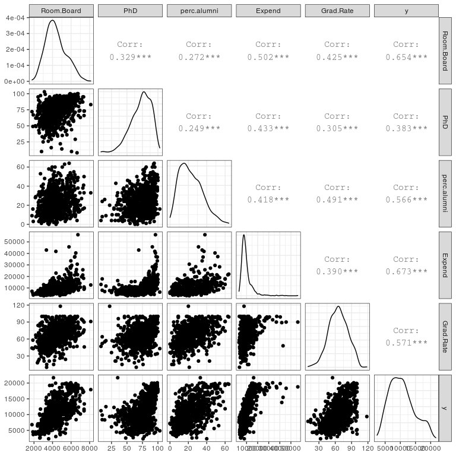

```r
ggpairs(df[, -1], progress = FALSE)
```

Generate a linear model for each numeric variable and inspect the p-values of the coefficients:

```r
lm.fits <- map(X[, -1], function(x) lm(y ~ x, data = df, subset = train))
p.values <- map_dbl(lm.fits, function(lm.fit) summary(lm.fit)$coefficients[2, 4])
p.values
```

```
  Room.Board          PhD  perc.alumni       Expend    Grad.Rate
9.544320e-76 1.554345e-24 1.604581e-56 2.834952e-81 3.212516e-56
```

When a liner model is generated from each of the variables separately, each variable has a significant p-value.

Generate a linear model from all 6 variables and inspect the coefficients:

```r
lm.fit.6 <- lm(y ~ Private + Room.Board + PhD + perc.alumni + Expend + Grad.Rate, data = df[train, ])
summary(lm.fit.6)
```

```
Call:
lm(formula = y ~ Private + Room.Board + PhD + perc.alumni + Expend +
    Grad.Rate, data = df[train, ])

Residuals:
    Min      1Q  Median      3Q     Max
-6872.9 -1378.1  -134.4  1278.7 10432.5

Coefficients:
              Estimate Std. Error t value Pr(>|t|)
(Intercept) -3.606e+03  4.898e+02  -7.361 5.90e-13 ***
PrivateYes   2.742e+03  2.366e+02  11.589  < 2e-16 ***
Room.Board   9.839e-01  9.471e-02  10.388  < 2e-16 ***
PhD          3.603e+01  6.319e+00   5.702 1.84e-08 ***
perc.alumni  5.683e+01  8.464e+00   6.714 4.31e-11 ***
Expend       2.094e-01  1.975e-02  10.604  < 2e-16 ***
Grad.Rate    2.789e+01  6.050e+00   4.610 4.89e-06 ***
---
Signif. codes:  0 ‘***’ 0.001 ‘**’ 0.01 ‘*’ 0.05 ‘.’ 0.1 ‘ ’ 1

Residual standard error: 2072 on 614 degrees of freedom
Multiple R-squared:  0.7455,    Adjusted R-squared:  0.743
F-statistic: 299.8 on 6 and 614 DF,  p-value: < 2.2e-16
```

All 6 variables are significant when combined in a linear model.

```r
gam.fits <- map(X[, -1], function(x) gam(y ~ s(x), data = df, subset = train))
```

Perform ANOVA:

```r
anova <- map2(lm.fits, gam.fits, function(f1, f2) anova(f1, f2))
anova
```

```
$Room.Board
Analysis of Variance Table

Model 1: y ~ x
Model 2: y ~ s(x)
  Res.Df        RSS Df Sum of Sq      F   Pr(>F)
1    619 5983628217
2    616 5845407588  3 138220629 4.8554 0.002399 **
---
Signif. codes:  0 ‘***’ 0.001 ‘**’ 0.01 ‘*’ 0.05 ‘.’ 0.1 ‘ ’ 1

$PhD
Analysis of Variance Table

Model 1: y ~ x
Model 2: y ~ s(x)
  Res.Df        RSS     Df  Sum of Sq      F    Pr(>F)
1    619 8744581868
2    616 7732040046 3.0001 1012541821 26.889 2.363e-16 ***
---
Signif. codes:  0 ‘***’ 0.001 ‘**’ 0.01 ‘*’ 0.05 ‘.’ 0.1 ‘ ’ 1

$perc.alumni
Analysis of Variance Table

Model 1: y ~ x
Model 2: y ~ s(x)
  Res.Df        RSS Df Sum of Sq     F Pr(>F)
1    619 6901110996
2    616 6889132573  3  11978424 0.357 0.7841

$Expend
Analysis of Variance Table

Model 1: y ~ x
Model 2: y ~ s(x)
  Res.Df        RSS     Df  Sum of Sq      F    Pr(>F)
1    619 5743061089
2    616 4066187923 3.0002 1676873167 84.673 < 2.2e-16 ***
---
Signif. codes:  0 ‘***’ 0.001 ‘**’ 0.01 ‘*’ 0.05 ‘.’ 0.1 ‘ ’ 1

$Grad.Rate
Analysis of Variance Table

Model 1: y ~ x
Model 2: y ~ s(x)
  Res.Df        RSS     Df Sum of Sq      F    Pr(>F)
1    619 6916557575
2    616 6650744719 2.9998 265812856 8.2071 2.312e-05 ***
---
Signif. codes:  0 ‘***’ 0.001 ‘**’ 0.01 ‘*’ 0.05 ‘.’ 0.1 ‘ ’ 1
```

Inspect the p-values:

```r
anova.p.values <- map(anova, 6) %>% map(2)
anova.p.values %>% as_vector()
```

```
  Room.Board          PhD  perc.alumni       Expend    Grad.Rate
2.399100e-03 2.362517e-16 7.840767e-01 7.004481e-46 2.312410e-05
```

Only the `perc.alumni` variable does not have a significant p-value. This means that the other 4 variables show evidence of a non-linear relationship with the response variable.

Construct a GAM consisting of linear terms for `Private` (categorical) and `perc.alumni`, and non-linear terms for `Room.Board`, `PhD`, `Expend` and `Grad.Rate`:

```r
gam.1 <- gam(y ~ Private + perc.alumni + s(Room.Board, 5) + s(PhD, 5) + s(Expend, 5) + s(Grad.Rate, 5), data = df, subset = train)
summary(gam.1)
```

```
Call: gam(formula = y ~ Private + perc.alumni + s(Room.Board, 5) +
    s(PhD, 5) + s(Expend, 5) + s(Grad.Rate, 5), data = df, subset = train)
Deviance Residuals:
     Min       1Q   Median       3Q      Max
-7503.25 -1127.48    43.97  1266.33  7468.96

(Dispersion Parameter for gaussian family taken to be 3559772)

    Null Deviance: 10354544612 on 620 degrees of freedom
Residual Deviance: 2128743990 on 598.0001 degrees of freedom
AIC: 11154.8

Number of Local Scoring Iterations: NA

Anova for Parametric Effects
                  Df     Sum Sq    Mean Sq F value    Pr(>F)
Private            1 2683149094 2683149094 753.742 < 2.2e-16 ***
perc.alumni        1 1251542969 1251542969 351.579 < 2.2e-16 ***
s(Room.Board, 5)   1 1608080049 1608080049 451.737 < 2.2e-16 ***
s(PhD, 5)          1  321414204  321414204  90.291 < 2.2e-16 ***
s(Expend, 5)       1  811470132  811470132 227.956 < 2.2e-16 ***
s(Grad.Rate, 5)    1  113516950  113516950  31.889 2.525e-08 ***
Residuals        598 2128743990    3559772
---
Signif. codes:  0 ‘***’ 0.001 ‘**’ 0.01 ‘*’ 0.05 ‘.’ 0.1 ‘ ’ 1

Anova for Nonparametric Effects
                 Npar Df  Npar F   Pr(F)
(Intercept)
Private
perc.alumni
s(Room.Board, 5)       4  2.5536 0.03805 *
s(PhD, 5)              4  1.5717 0.18024
s(Expend, 5)           4 27.3352 < 2e-16 ***
s(Grad.Rate, 5)        4  1.5875 0.17602
---
Signif. codes:  0 ‘***’ 0.001 ‘**’ 0.01 ‘*’ 0.05 ‘.’ 0.1 ‘ ’ 1
```

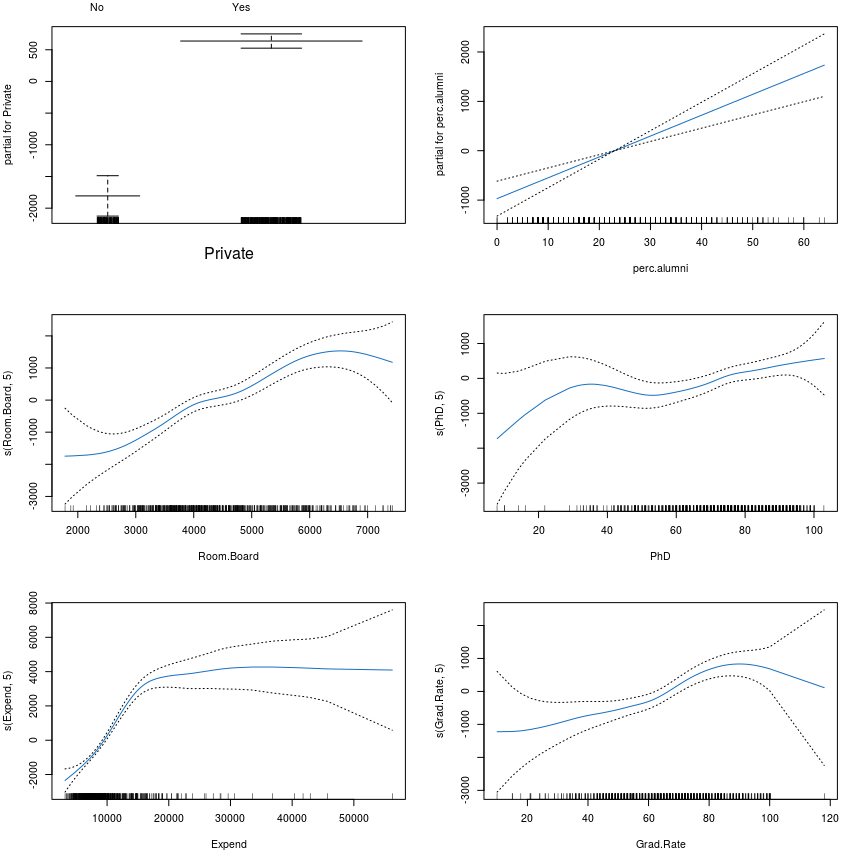

```r
par(mfrow = c(3, 2))
plot(gam.1, se = TRUE, col = ISLR_blue)
```

### (c)

Linear model:

```r
# Predictions and test error:
lm.pred <- predict(lm.fit.6, newdata = df[test, ])
lm.test.error <- mean((lm.pred - y[test])^2)

# R-squared:
test.avg <- mean(y[test])
lm.r2 <- 1 - lm.test.error / mean((test.avg - y[test])^2)
lm.r2
```

```
[1] 0.7511881
```

GAM:

```r
# Predictions and test error:
gam.pred <- predict(gam.1, newdata = df[test, ])
gam.test.error <- mean((gam.pred - y[test])^2)

# R-squared:
gam.r2 <- 1 - gam.test.error / mean((test.avg - y[test])^2)
gam.r2
```

```
[1] 0.7880317
```

The GAM outperforms the linear model in terms of test R-squared value. This indicates that the GAM was able to model some non-linearity in the data to improve the fit.

### (d)

For which variables, if any, is there evidence of a non-linear relationship with the response?

```r
X <- College[, -c(1, 9)]
y <- College[, 9]
df <- data.frame(X, y)
rownames(df) <- NULL

lm.fits <- map(X, function(x) lm(y ~ x, data = df))
gam.fits <- map(X, ~ gam(y ~ s(.x), data = df))
#gam.fits.2 <- lapply(X, function(x) gam(y ~ s(x), data = df))
```

Perform ANOVA and inspect the p-values:

```r
anova <- map2(lm.fits, gam.fits, function(f1, f2) anova(f1, f2))
anova.p.values <- map(anova, 6) %>% map(2)
anova.p.values %>% as_vector()
```

```
        Apps       Accept       Enroll    Top10perc    Top25perc  F.Undergrad  P.Undergrad   Room.Board        Books
5.441528e-03 1.341571e-04 2.301487e-04 1.788396e-01 2.280959e-02 9.508004e-05 1.582406e-14 1.777160e-03 6.958733e-03
    Personal          PhD     Terminal    S.F.Ratio  perc.alumni       Expend    Grad.Rate
3.486527e-06 3.279716e-18 1.397835e-11 8.339415e-10 8.937113e-01 1.220277e-54 1.584495e-05
```

Only `Top10perc` and `perc.alumni` have non-significant p-values. All other variables gave low p-values indicating evidence for non-linearity.

Plot the GAM’s and inspect visually:

```r
# Use variable names and formula so that the GAM's can be plotted:
vars <- names(X)
vars <- set_names(vars)

gam.fits <- lapply(vars, function(x) {
  gam(as.formula(paste("y ~ s(", x, ", 5)")), data = df)
})
```

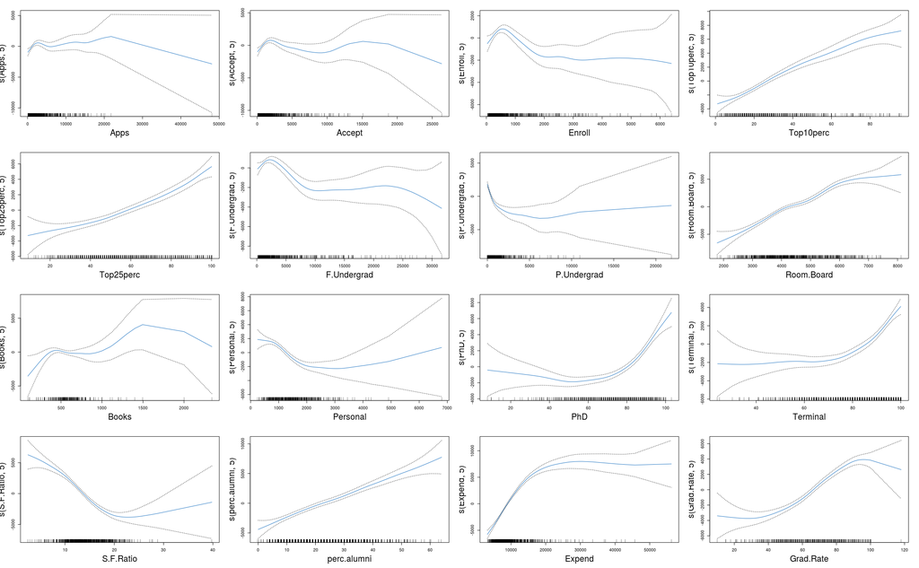

```r
par(mfrow = c(4, 4))
invisible(lapply(gam.fits, function(gam) plot(gam, se = TRUE, col = ISLR_blue, cex.lab = 2)))
```

In the plots, `Top10perc` and `perc.alumni` look somewhat linear, while the other variables exhibit varying degrees of non-linearity.

## Exercise 11

### (a)

Generate a response $Y$ and two predictors $X_1$ and $X_2$ , with $n = 100$:

```r
set.seed(1)
x1 <- rnorm(100, mean = 5, sd = 3)
x2 <- rnorm(100, mean = 10, sd = 5)
eps <- rnorm(100, sd = 0.2)
y <- 1 + 1.2*x1 - 2*x2 + eps
df <- data.frame(x1, x2, y)
```

Plot:

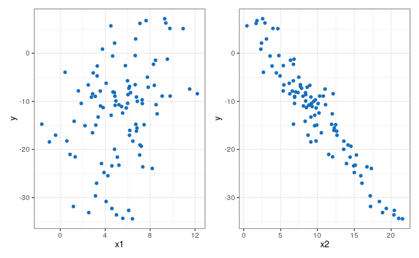

```r
p1 <- ggplot(df) +
  geom_point(aes(x1, y), color = ISLR_blue)
p2 <- ggplot(df) +
  geom_point(aes(x2, y), color = ISLR_blue)
p1 + p2
```

### (b)

Initialize $\hat{\beta_1}$:

```r
beta1 <- 1
```

### (c)

Keeping $\hat{\beta_1}$ fixed, fit the model
$$Y - \hat{\beta_1}X_1 = \beta_0 + \beta_2X_2 + \epsilon:$$

```r
a <- y - beta1*x1
beta2 <- lm(a ~ x2)$coef[2]
beta2
```

```
       x2
-2.002251
```

The value for $\hat{\beta_2}$ is very close to the true value, $\beta_2 = -2$.

### (d)

Keeping $\hat{\beta_2}$ fixed, fit the model
$$Y - \hat{\beta_2}X_2 = \beta_0 + \beta_1X_1 + \epsilon:$$

```r
a <- y - beta2*x2
beta1 <- lm(a ~ x1)$coef[2]
beta1
```

```
      x1
1.201407
```

Again, the value for $\hat{\beta_1}$ is very close to the true value, $\beta_1 = 1.2$.

### (e)

Repeat parts (c) and (d) 1000 times and plot the estimates of $\hat{\beta_0}$, $\hat{\beta_1}$ and $\hat{\beta_2}$:

```r
k = 1000
coeffs <- matrix(data = NA, nrow = k, ncol = 3, dimnames = list(NULL, c("beta0", "beta1", "beta2")))

coeffs[1, 2] <- 1 # Initialize `beta1`
a <- y - coeffs[1, 2]*x1
coeffs[1, 3] <- lm(a ~ x2)$coef[2] # `beta2`
coeffs[1, 1] <- lm(a ~ x2)$coef[1] # `beta0`

# Use a for loop to iterate over the remaining (n - 1) values:
for(i in 2:k) {
  a <- y - coeffs[i - 1, 3]*x2
  coeffs[i, 2] <- lm(a ~ x1)$coef[2]

  a <- y - coeffs[i, 2]*x1
  coeffs[i, 3] <- lm(a ~ x2)$coef[2]
  coeffs[i, 1] <- lm(a ~ x2)$coef[1]
}

coeffs <- data.frame(k = 1:k, coeffs)
```

The coefficients converge to their true values very quickly as this plot of the first 20 iterations shows:

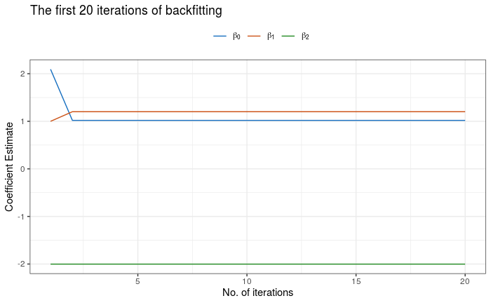

```r
p1 <- coeffs %>%
  head(20) %>%
  pivot_longer(cols = contains("beta"), names_to = "beta", values_to = "estimate") %>%
  ggplot() +
  geom_line(aes(k, estimate, color = beta)) +
  labs(x = "No. of iterations", y = "Coefficient Estimate", color = NULL,
       title = "The first 20 iterations of backfitting") +
  scale_color_manual(breaks = c("beta0", "beta1", "beta2"),
                       values = c(ISLR_blue, ISLR_orange, "forestgreen"),
                       labels = c(expression(beta[0]), expression(beta[1]), expression(beta[2]))) +
  theme(legend.position = "top")
p1
```

### (f)

```r
fit <- lm(y ~ ., data = df)
fit.coeffs <- fit$coefficients
fit.coeffs
```

```
(Intercept)          x1          x2
   1.019421    1.201407   -2.002139
```

Mark the least squares on the plot using dotted lines:

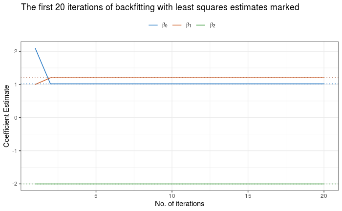

```r
p1 +
  geom_hline(yintercept = fit.coeffs[1], color = ISLR_blue, linetype = "dotted") +
  geom_hline(yintercept = fit.coeffs[2], color = ISLR_brown, linetype = "dotted") +
  geom_hline(yintercept = fit.coeffs[3], color = "forestgreen", linetype = "dotted") +
  ggtitle("The first 20 iterations of backfitting with least squares estimates marked")
```

### (g)

The estimates match after very few iterations.

## Exercise 12

### (a)

```r
start <- bh_start_timer()
```

```
[1] "Start time: 2021-04-16 14:44:47"
```

```r
set.seed(2)
n <- 100 # no. of observations
p <- 10 # no. of predictors (p < n)
X <- matrix(NA, nrow = n, ncol = p + 1) # (p + 1) for beta0
X[ , 1] <- rep(1, n) # column of 1's for beta0

# Randomly initialize X:
for(i in 2:(p+1)) {
  mean <- sample(-10:10, 1)
  sd <- sample(1:5, 1)
  X[ , i] <- rnorm(n, mean, sd)
}

# Randomly initialize beta:
# beta <- seq(-100, 100, length = 500) %>%
#           sample(p + 1, replace = TRUE)
beta <- seq(-5, 5, length = 500) %>%
          sample(p + 1, replace = TRUE)

# y = beta * X:
y <- mapply("*", as.data.frame(X), beta) %>%
     apply(1, sum)

K <- 500 # max no. of iterations for backfitting

# Estimated beta:
beta.hat <- matrix(NA, nrow = K, ncol = p + 1) # (p + 1) for beta 0
beta.hat[1, ] <- rep(1, p + 1) # initialize all beta estimates to 1

# Backfitting: use a loop to update the estimates (K-1) more times:
for(k in 2:K) {
  if(k %% 25 == 0) { # check for convergence every 25 iterations
    print(str_c("k: ", k, "..."))
    if(sum(abs(apply(beta.hat[(k-6):(k-2), ], 2, mean) - beta.hat[k-1, ])) / p < 1e-02) {
      break # convergence when last five rows show no change
    }
  }
  for(i in 1:(p+1)) {
    ### Hold all but one beta.hat fixed and update it:
    a <- y - (mapply("*", as.data.frame(X[ , -i]), beta.hat[k-1, -i]) %>% apply(1, sum))
    if(i != 1) {
      beta.hat[k, i] <- lm(a ~ X[ , i], data = data.frame(X[ , i], y))$coef[2]
    } else {
      beta.hat[k, i] <- lm(a ~ X[ , i], data = data.frame(X[ , i], y))$coef[1] # beta0
    }
  }
}
```

```
[1] "k: 25..."
```

```r
end <- bh_end_timer()
```

```
[1] "End time: 2021-04-16 14:44:50"
```

```r
bh_run_time(start, end)
```

```
[1] "Run time: 2.46 secs"
```

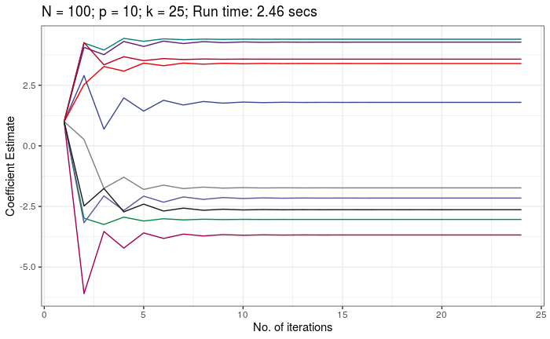

```r
# Plot the values for beta up until the value of k when convergence occurred:
p1 <- cbind(data.frame(k = 1:(k-1)), beta.hat[1:(k-1) ,-1]) %>% # k-1 because it stops at the kth iteration leaving NA's
  pivot_longer(!contains("k"), names_to = "beta", values_to = "estimate") %>%
  ggplot() +
  geom_line(aes(k, estimate, color = beta), show.legend = FALSE) +
  labs(x = "No. of iterations", y = "Coefficient Estimate",
       title = str_c("N = ", n, "; p = ", p, "; k = ", k, "; ", bh_run_time(start, end))) +
  ggsci::scale_color_aaas()
p1
```

[^1]: James G, Witten D, Hastie T, Tibshirani R (2013). *An Introduction to Statistical Learning: with Applications in R*. Springer, 1st edition.